# chapter2: Regression and model validation

## Diagnostic plots

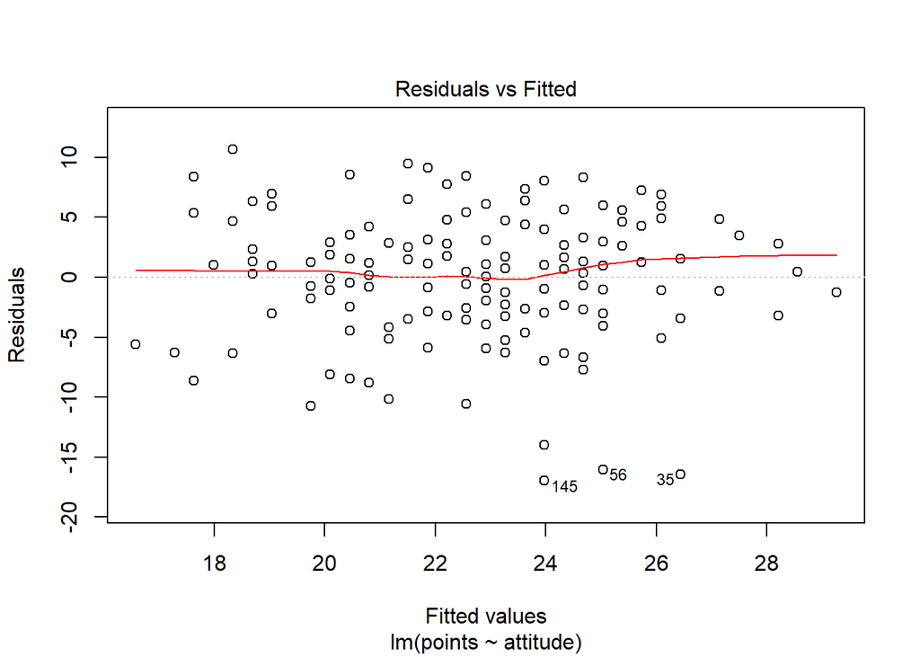

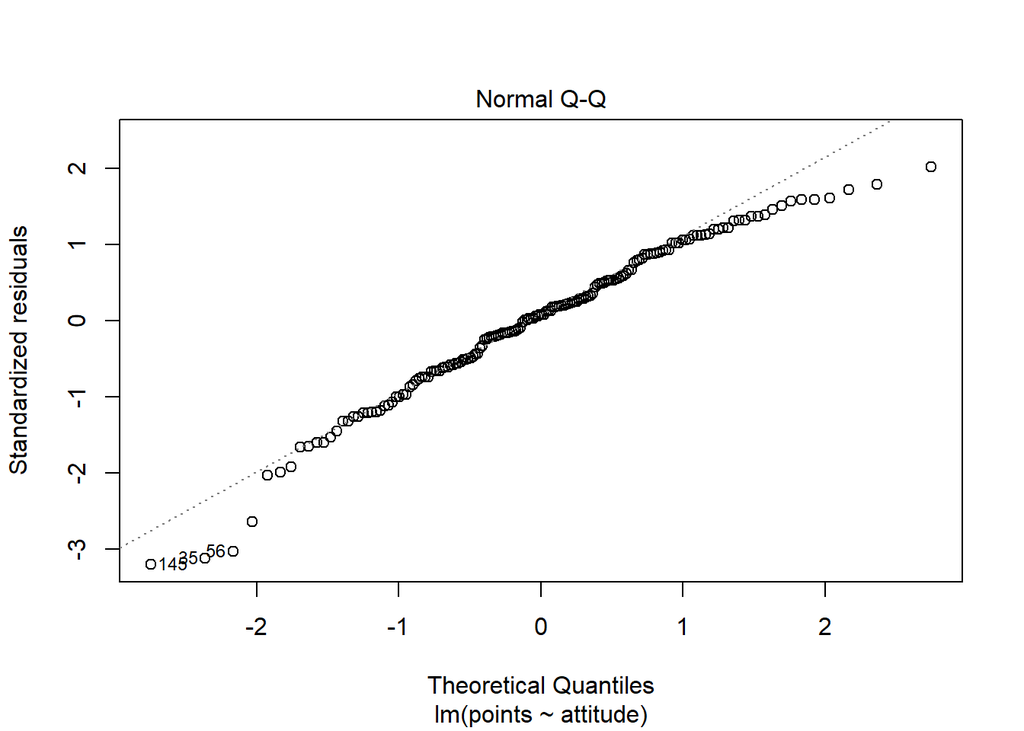

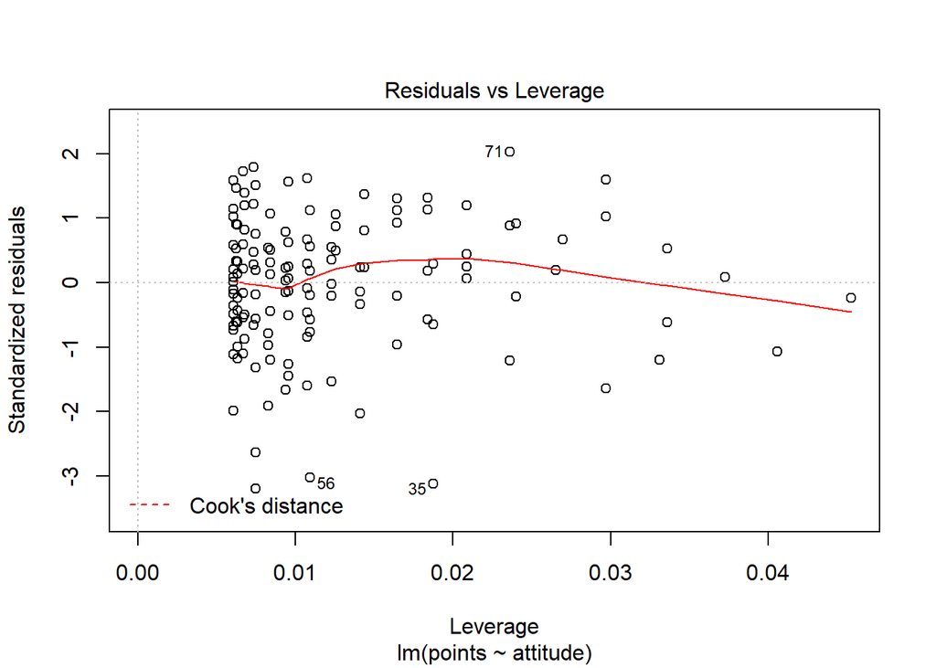

```r
plot(my_model3, which=c(1,2,5))
```

1. Interpretation on Diagnostic plot
- Linear regression model is based on mainly two assumption, first, the linearity of the target variable is assumed to be linear and second, errors in the model are normally distributed with no correlation, contant variance and independent of expalanotry variables.
- Based on QQ plots we can say the our errors are close to normally distributed as dots falls closer to the line of fit.
- The uniform distribution of residuals vs model prediction, suggest that error size is constant and there is no effect of explanotry variable on it.
- The Residual vs leverage plot assist in identifying the extreme outliers in the explanotry variables. Any sort of trend on that plot will point towards an outlier. Since we do not see such trend in Residual vs leverage plot we can say that there was a regular leverage in out model.
- As our model was well fitted with the assumptions, we can conclude that our model is valid.